# Evolution of female death from cancer in the last decades using GapMinder Dataset

- Introduction
- Data Wrangling
- Exploratory Data Analysis
- Conclusions

## Introduction

This analysis uses the data available in GapMinder dataset on women health. The analysis looks more specifically into the different types of cancer causing death of women (breast, colon and rectum, liver, lung and stomach) and the worlwide evolution of the number of deaths caused by each one in the last decades. The evolution of some potential risk factors in the last decades is also analysed.

The following questions are targeted: how did the number of deaths of women caused by cancer evolve in the last decades? At the world level and for some specific countries?

```python
#loading libraries and defining plots settings
import pandas as pd
import matplotlib
import matplotlib.pyplot as plt
from os import listdir
from itertools import product
import numpy as np
from cycler import cycler
matplotlib.rcParams.update({'font.size': 16})
cmap = matplotlib.cm.get_cmap('tab20')
matplotlib.rcParams['axes.prop_cycle'] = cycler(color=cmap(range(20)))
```

## Data Wrangling

### General Properties

```python
#loading csv files from GapMinder dataset on health data (different cancer types and risks) into pandas dataframes
files=listdir('Health')
temp=pd.read_csv('Health/'+files[0])
years=temp.columns[1:].astype('int64').to_list()
countries=temp.country.to_list()
df=pd.DataFrame([list(yc) for yc in product(years,countries)],columns=['years','countries'])
df[files[0][:-4]]=np.nan
for yc in product(years,countries):
    df.loc[(df.years==yc[0])&(df.countries==yc[1]),files[0][:-4]]=temp.loc[temp.country==yc[1],str(yc[0])].item()
#merge dataframes into one
for file in files[1:]:
    temp=pd.read_csv('Health/'+file)
    years=temp.columns[1:].astype('int64').to_list()
    countries=temp.country.to_list()
    temp_res=pd.DataFrame([list(yc) for yc in product(years,countries)],columns=['years', 'countries'])
    temp_res[file[:-4]]=np.nan
    for yc in product(years,countries):
        temp_res.loc[(temp_res.years==yc[0])&(temp_res.countries==yc[1]),file[:-4]]=temp.loc[temp.country==yc[1],str(yc[0])].item()
    df=df.merge(temp_res,on=['years','countries'],how='outer')
```

### Missing Data

Let's look at the amount of missing data in average in each column of the dataframe, then missing data per year and per coutry.

```python
countries=df.countries.unique()
years=df.years.unique()
cancers=[col for col in df.columns if 'cancer' in col]
risks=[col for col in df.columns[2:] if 'cancer' not in col]

[print('{} : {}% missing'.format(j,round(100*i/df.shape[0],2))) for i,j in zip(df[cancers].isnull().sum(),df[cancers].isnull().sum().index)]
print()
[print('{} : {}% missing'.format(j,round(100*i/df.shape[0],2))) for i,j in zip(df[risks].isnull().sum(),df[risks].isnull().sum().index)]
```

```
breast_cancer_number_of_female_deaths : 28.08% missing
colonandrectum_cancer_number_of_female_deaths : 28.08% missing
liver_cancer_number_of_female_deaths : 28.08% missing
lung_cancer_number_of_female_deaths : 28.08% missing
stomach_cancer_number_of_female_deaths : 28.08% missing

alcohol_consumption_per_adult_15plus_litres : 94.25% missing
blood_pressure_sbp_women_mmhg : 21.92% missing
body_mass_index_bmi_women_kgperm2 : 21.92% missing
cholesterol_fat_in_blood_women_mmolperl : 21.92% missing
smoking_women_percent_of_women_over_age_15 : 94.44% missing
```

```
[None, None, None, None, None]
```

Same amount of data missing for each type of cancer (28%), high number of missing data for two risk factors (94% for the alcohol consumption and percentage of smoking women over age of 15).

#### Further look into missing data

Let's display in graphs the amount of data missing per year for the cancers and risk factors.

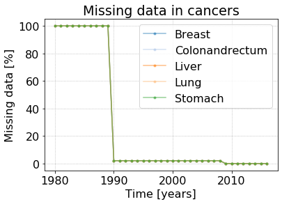

```python
plt.figure()
plt.plot(df.years.groupby(df.years).count().index,
         100*df[cancers].isnull().groupby(df.years).sum().values/np.reshape(df.years.groupby(df.years).count().values, (-1,1)),
         '.-',alpha=.5)
plt.grid(linestyle=':')
plt.legend([c.split('_')[0].capitalize() for c in cancers],bbox_to_anchor=(1,1))
plt.title('Missing data in cancers')
plt.xlabel('Time [years]')
plt.ylabel('Missing data [%]')
plt.show()
```

100% of cancer data missing earlier than 1990; this time period should be ignored from further analysis.

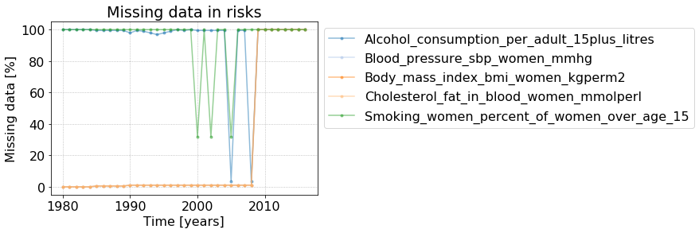

```python
plt.figure()
#plt.plot(df.years.groupby(df.years).count(),'ro-')
plt.plot(df.years.groupby(df.years).count().index,
         100*df[risks].isnull().groupby(df.years).sum().values/np.reshape(df.years.groupby(df.years).count().values, (-1,1)),
         '.-',alpha=.5)
plt.grid(linestyle=':')
plt.legend([c.capitalize() for c in risks],bbox_to_anchor=(1,1))
plt.title('Missing data in risks')
plt.xlabel('Time [years]')
plt.ylabel('Missing data [%]')
plt.show()
```

Again we notice that most of the data is missing for the alcohol consumption (except in 2005 and 2008) and percentage of women smoking over age 15 (except in 2000, 2002 and 2005).The other risk factors are overlapping with 100% of data missing from 2009 and after.

The following two boxplot graphs present the distribution of missing data per country for each type of cancer in the first graph and for each risk factor in the second.

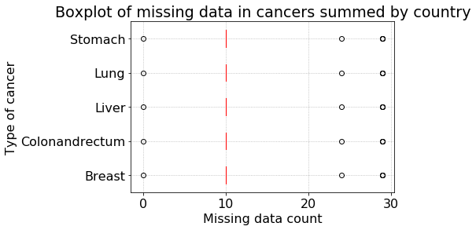

```python
plt.figure()
plt.boxplot(df[cancers].isnull().groupby(df.countries).sum().transpose(),vert=False,medianprops={'color':'red'})
plt.yticks(range(1,6),[c.split('_')[0].capitalize() for c in cancers],rotation=0)
plt.grid(linestyle=':')
plt.title('Boxplot of missing data in cancers summed by country')
plt.ylabel('Type of cancer')
plt.xlabel('Missing data count')
plt.show()
```

The same distribution of missing data is observed over each cancer type with a median value of ten.

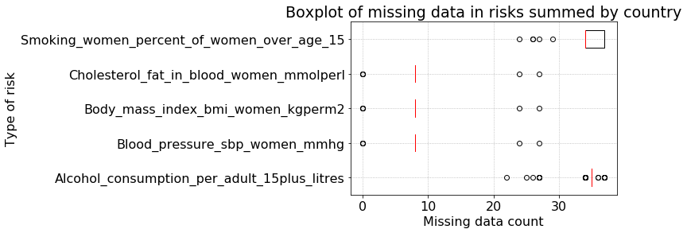

```python
plt.figure()
plt.boxplot(df[risks].isnull().groupby(df.countries).sum().transpose(),vert=False,medianprops={'color':'red'})
plt.yticks(range(1,6),[c.capitalize() for c in risks],rotation=0)
plt.grid(linestyle=':')
plt.title('Boxplot of missing data in risks summed by country')
plt.ylabel('Type of risk')
plt.xlabel('Missing data count')
plt.show()
```

The distribution of missing data for each risk factor is presented in the boxplot above. The same information observed at the beginning can be seen again: the alcohol consumption and percentage of smoking women present a higher rate of missing data with a median value around 35.

## Exploratory Data Analysis

The available data on the number women deaths and few risk factors per year and per country has been loaded and reshaped into a pandas dataframe for further analysis. The cells below give a highlight on the number of deaths and risk factors averaged per year, in the first cell, and per country, in the second.

The research questions are then answered with graphical support in the following.

```python
df.groupby(by='years').mean().head()
```

| years | alcohol_consumption_per_adult_15plus_litres | blood_pressure_sbp_women_mmhg | body_mass_index_bmi_women_kgperm2 | breast_cancer_number_of_female_deaths | cholesterol_fat_in_blood_women_mmolperl | colonandrectum_cancer_number_of_female_deaths | liver_cancer_number_of_female_deaths | lung_cancer_number_of_female_deaths | smoking_women_percent_of_women_over_age_15 | stomach_cancer_number_of_female_deaths |
| --- | --- | --- | --- | --- | --- | --- | --- | --- | --- | --- |
| 1980 | NaN | 128.476190 | 23.472487 | NaN | 5.065503 | NaN | NaN | NaN | NaN | NaN |
| 1981 | NaN | 128.396825 | 23.553439 | NaN | 5.053757 | NaN | NaN | NaN | NaN | NaN |
| 1982 | NaN | 128.349206 | 23.631217 | NaN | 5.041111 | NaN | NaN | NaN | NaN | NaN |
| 1983 | NaN | 128.264550 | 23.709524 | NaN | 5.027989 | NaN | NaN | NaN | NaN | NaN |
| 1984 | NaN | 128.174603 | 23.780952 | NaN | 5.014497 | NaN | NaN | NaN | NaN | NaN |

```python
df.groupby(by='countries').mean().head()
```

| countries | years | alcohol_consumption_per_adult_15plus_litres | blood_pressure_sbp_women_mmhg | body_mass_index_bmi_women_kgperm2 | breast_cancer_number_of_female_deaths | cholesterol_fat_in_blood_women_mmolperl | colonandrectum_cancer_number_of_female_deaths | liver_cancer_number_of_female_deaths | lung_cancer_number_of_female_deaths | smoking_women_percent_of_women_over_age_15 | stomach_cancer_number_of_female_deaths |
| --- | --- | --- | --- | --- | --- | --- | --- | --- | --- | --- | --- |
| Afghanistan | 1998.0 | 0.025 | 123.827586 | 20.668966 | 1714.481481 | 4.450690 | 614.296296 | 255.148148 | 424.074074 | NaN | 906.851852 |
| Albania | 1998.0 | 6.985 | 130.172414 | 25.189655 | 169.000000 | 4.956552 | 88.544444 | 89.611111 | 152.862963 | 0.040 | 131.629630 |
| Algeria | 1998.0 | 0.825 | 130.724138 | 25.003448 | 1450.000000 | 4.910690 | 582.074074 | 162.037037 | 286.740741 | 0.003 | 386.814815 |
| Andorra | 1998.0 | 12.850 | 128.862069 | 25.965517 | 12.718519 | 5.744483 | 8.623704 | 1.224074 | 6.764444 | 0.292 | 3.134444 |
| Angola | 1998.0 | 5.485 | 130.000000 | 21.406897 | 710.703704 | 4.603793 | 280.518519 | 253.185185 | 213.407407 | NaN | 261.444444 |

### Research Question 1: How did the number of deaths of women caused by cancer evolve in the last decades at the world level?

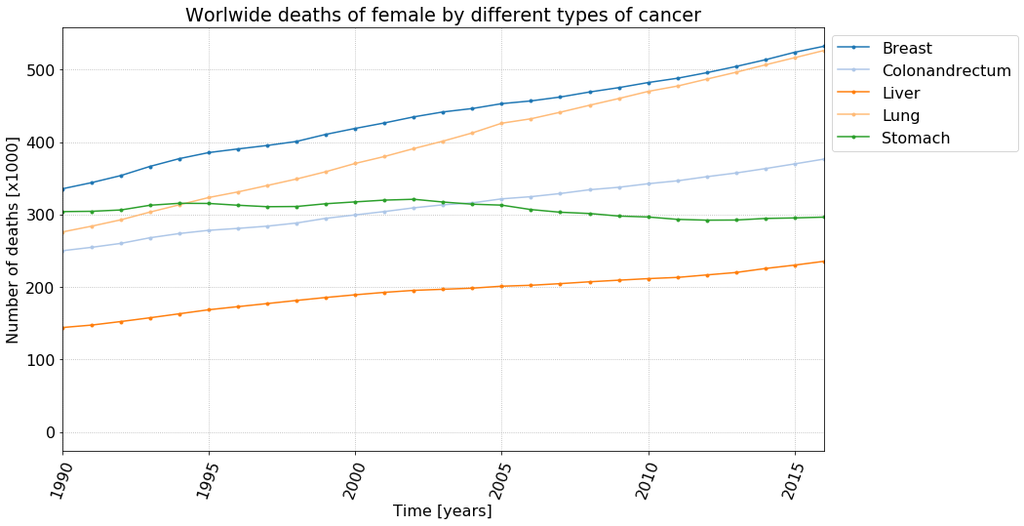

```
37.0% difference between 1990 and 2016 for breast cancer.
33.6% difference between 1990 and 2016 for colonandrectum cancer.
38.8% difference between 1990 and 2016 for liver cancer.
47.6% difference between 1990 and 2016 for lung cancer.
-2.5% difference between 1990 and 2016 for stomach cancer.
```

```
[None, None, None, None, None]
```

```python
plt.figure(figsize=(14,8))
plt.plot(df.groupby(by='years').sum()[cancers]/1000,'.-')
plt.grid(linestyle=':')
plt.title('Worlwide deaths of female by different types of cancer')
plt.xticks(rotation=70)
plt.legend([c.split('_')[0].capitalize() for c in cancers],bbox_to_anchor=(1,1),ncol=1)
plt.xlabel('Time [years]')
plt.ylabel('Number of deaths [x1000]')
plt.xlim(1990,2016)
plt.show()
[print('{}% difference between 1990 and 2016 for {} cancer.'.format(round(100*(df.loc[df.years==2016,c].sum()-df.loc[df.years==1990,c].sum())/max(df.loc[df.years==2016,c].sum(),df.loc[df.years==1990,c].sum()),1),c.split('_')[0])) for c in cancers]
```

The previous graph shows a significant increase (34 to 48%) of number of women deaths caused by the breast, colon and rectum, liver and lung cancers at the world level from 1990 to 2016. The number of deaths caused by stomach cancer remained slightly constant at the world level in the last decades.

### Research Question 2: How did the number of deaths of women caused by cancer evolve in the last decades for some specific countries?

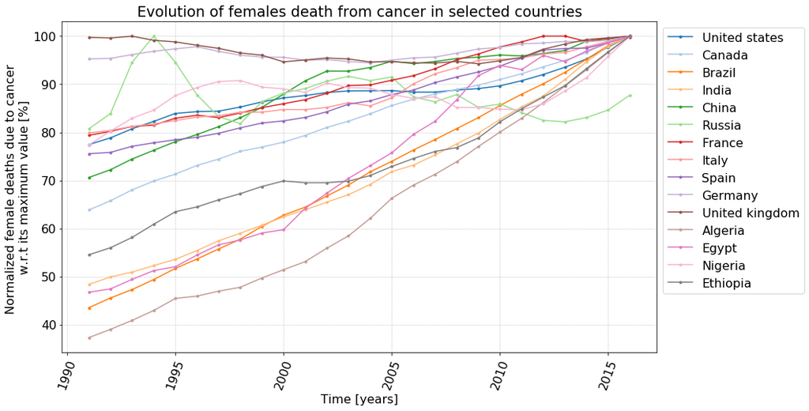

```
['22.6% difference between 1991 and 2016 for United States.',
 '36.2% difference between 1991 and 2016 for Canada.',
 '56.5% difference between 1991 and 2016 for Brazil.',
 '51.6% difference between 1991 and 2016 for India.',
 '29.4% difference between 1991 and 2016 for China.',
 '8.0% difference between 1991 and 2016 for Russia.',
 '20.5% difference between 1991 and 2016 for France.',
 '20.1% difference between 1991 and 2016 for Italy.',
 '24.4% difference between 1991 and 2016 for Spain.',
 '4.7% difference between 1991 and 2016 for Germany.',
 '0.3% difference between 1991 and 2016 for United Kingdom.',
 '62.7% difference between 1991 and 2016 for Algeria.',
 '53.3% difference between 1991 and 2016 for Egypt.',
 '22.6% difference between 1991 and 2016 for Nigeria.',
 '45.5% difference between 1991 and 2016 for Ethiopia.']
```

```python
cancers=[col for col in df.columns[2:] if 'cancer' in col]
countries=['United States','Canada','Brazil',
           'India','China','Russia',
           'France','Italy','Spain','Germany','United Kingdom',
           'Algeria','Egypt','Nigeria','Ethiopia']
plt.figure(figsize=(14,8))
[plt.plot(df.loc[(df.countries==country)&(df.years>1990),'years'],
          100*df.loc[(df.countries==country)&(df.years>1990),cancers].sum(axis=1)/df.loc[(df.countries==country)&(df.years>1990),cancers].sum(axis=1).max(),
          '.-') for country in countries]
plt.grid(linestyle=':')
plt.title('Evolution of females death from cancer in selected countries')
plt.xticks(rotation=70)
plt.legend([c.capitalize() for c in countries],bbox_to_anchor=(1,1),ncol=1)
plt.xlabel('Time [years]')
plt.ylabel('Normalized female deaths due to cancer \nw.r.t its maximum value [%]')
plt.show()
['{}% difference between 1991 and 2016 for {}.'.format(np.round(100*(df.loc[(df.years==2016)&(df.countries==c),cancers].sum(axis=1).values-df.loc[(df.years==1991)&(df.countries==c),cancers].sum(axis=1).values)/max(df.loc[(df.years==2016)&(df.countries==c),cancers].sum(axis=1).values,df.loc[(df.years==1991)&(df.countries==c),cancers].sum(axis=1).values),1)[0],c) for c in countries]
```

### Research Question 3: How did the risk factors evolve in the last decades at the world level?

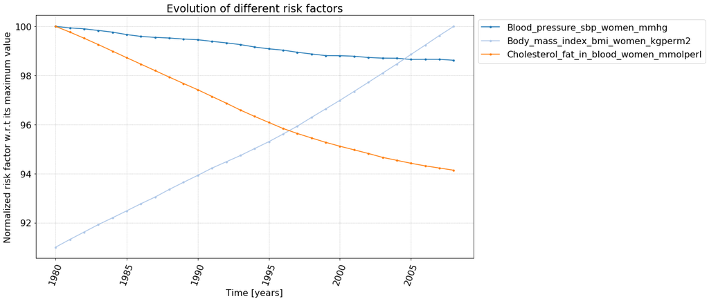

```
-1.4% difference between 1980 and 2008 for blood_pressure_sbp_women_mmhg.
9.0% difference between 1980 and 2008 for body_mass_index_bmi_women_kgperm2.
-5.9% difference between 1980 and 2008 for cholesterol_fat_in_blood_women_mmolperl.
```

```
[None, None, None]
```

```python
risks=[r for r in risks if ('alcohol' not in r)&('smoking' not in r)]
plt.figure(figsize=(14,8))
plt.plot(100*df.loc[df.years<2009].groupby(by='years').sum()[risks]/df.loc[df.years<2009].groupby(by='years').sum().max()[risks],'.-')
plt.grid(linestyle=':')
plt.title('Evolution of different risk factors')
plt.xticks(rotation=70)
plt.legend([c.capitalize() for c in risks],bbox_to_anchor=(1,1),ncol=1)
plt.xlabel('Time [years]')
plt.ylabel('Normalized risk factor w.r.t its maximum value')
plt.show()
[print('{}% difference between 1980 and 2008 for {}.'.format(round(100*(df.loc[df.years==2008,c].sum()-df.loc[df.years==1980,c].sum())/max(df.loc[df.years==2008,c].sum(),df.loc[df.years==1980,c].sum()),1),c)) for c in risks]
```

The analysis on the potential risk factors is not very conclusive. Two interesting risk factors (alcohol consumption and smoking) were discarded from the analysis because of the significant amount of data missing. The remaining risk factors do not present a significant variation on the available time period (1980 to 2008) and cannot really be used as explanatory variables for the types of cancer studied. Also the last 8 years of data are missing where an increase of deaths by cancer was observed.

## Conclusions

A significant increase (34 to 48%) of number of women deaths caused by the breast, colon and rectum, liver and lung cancers has been observed at the world level from 1990 to 2016. The number of deaths caused by stomach cancer remained slightly constant at the world level in the last decades.

The analysis on potential risk factors was not conclusive and should be discarded due to missing data.